# Debata pre zaciatocníkov (augustový turnus)

Zpět na rozcestník zpětné vazby | Tento report we Wordu | Data v CSV

## Hodnocení kurzu

Průměrná známka:

| Blok setkání | Průměrná známka |
| --- | --- |
| A | 1.93 |
| B | 1.39 |
| oba | 1.64 |

### Hodnocení po dnech

A a B jsou bloky (A je 9-10:30, B je 11-12:30)

Známky jsou jako ve škole: 1 je nejlepší, 5 nejhorší

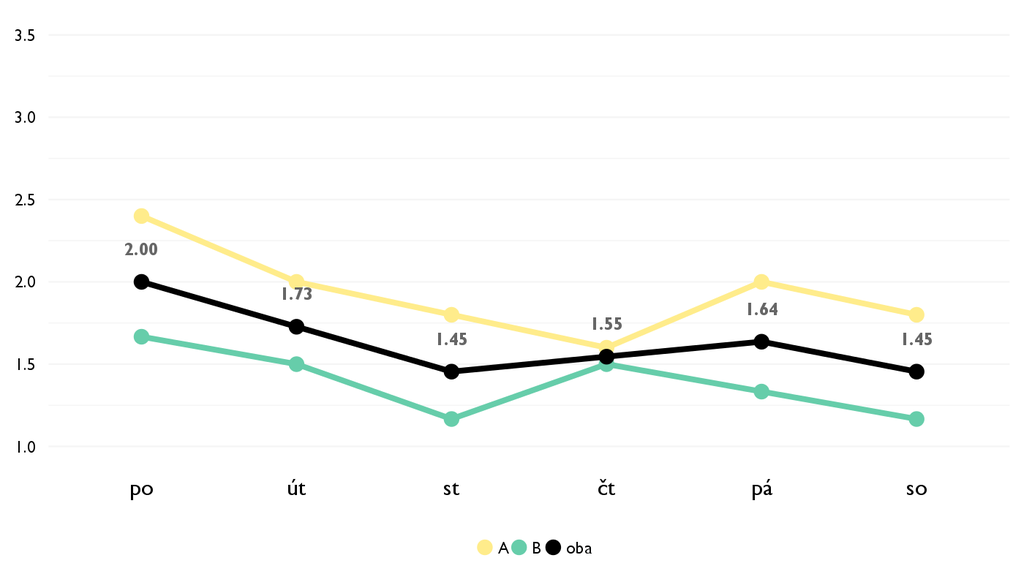

### Co se na kurzu líbilo

- Sposob vyucovania vysvetlovanie teorie prepojene s praxou mtaktiez potreba debaty v dnesnej spolocnosti
- Systematická výuka a vzájemná interakce mezi námi
- Struktura kurzu, kdy jsme sli od nejlehciho k tezsimu a podnetne poznamky lektoru, stejne jako vhodne doplnene energizing aktivity. Blazky a Juro, jste moji hrdinove!!
- To, že bol veľmi energický a interaktívny.
- Přístup chalanov- upřímnost, spontannost a cukriky :3
- Naucil som sa co je Debata a aj som sa naucil debatovat, hodiny boli zaujimave odniesol som si z nich vela a preto lebo to urcite vyuzijem
- Velmi dobrý lektory zábavná výuka interaktivní hry
- To ze sem se naučila komunikovat s ludmi a vytvářet strukturu argumentu.
- Možnost debatovat a zjistit něco o tom. Hlavně přátelskost lektorů.
- ze som a naucila zakladnu strukturu debaty
- Najviac sa mi pacilo to ze som sa naucila ako spravne debatovat a obhajit si svoj nazor.

### Co na kurzu změnit

- Nic takto je to efektivne
- Mluvit trochu pomaleji, přece jenom, slovenština… :D
- Mozna trosku lepe vysvetlit jak se debata (resp. v debate) definuje.
- Neviem o ničom.
- Viac debat?
- Nic netreba menit je to vyborne
- Viac debaty aby sme si to výškusali.
- Možná více času, aby se mohlo více procvičit.

## Hodnocení lektora

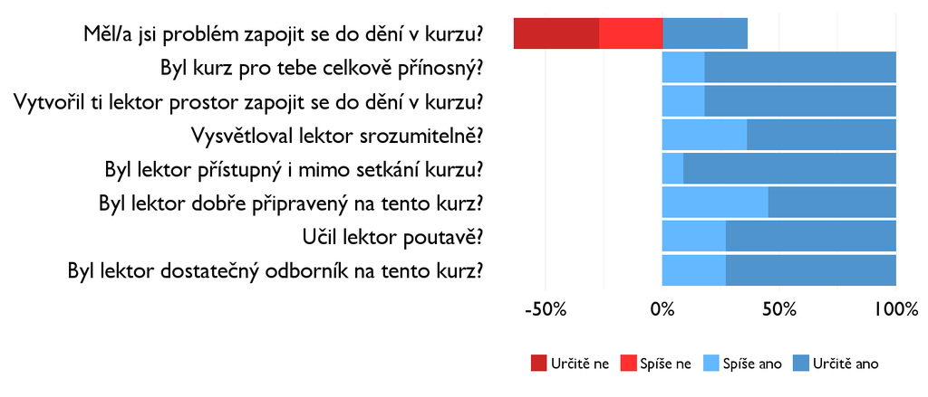

### Komentáře k lektorovi

- Byli jste fakt super, oba :)
- Obaja ste super chlapci, len tak ďalej ;)
- Možno mimo-seminarove sessions a debaty
- Juro a Blašky ucili aby to bolo zrozumitelne

## Náročnost kurzu

### **Jak hodnotíš náročnost…**

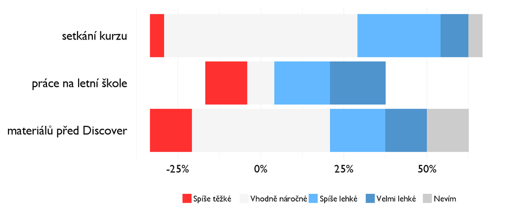

## Didaktika

Na některé otázky jsme se na augustovém turnuse neptali - tam uvidíte nadpis bez grafu.

### Jak lektor učí a měl by to změnit?

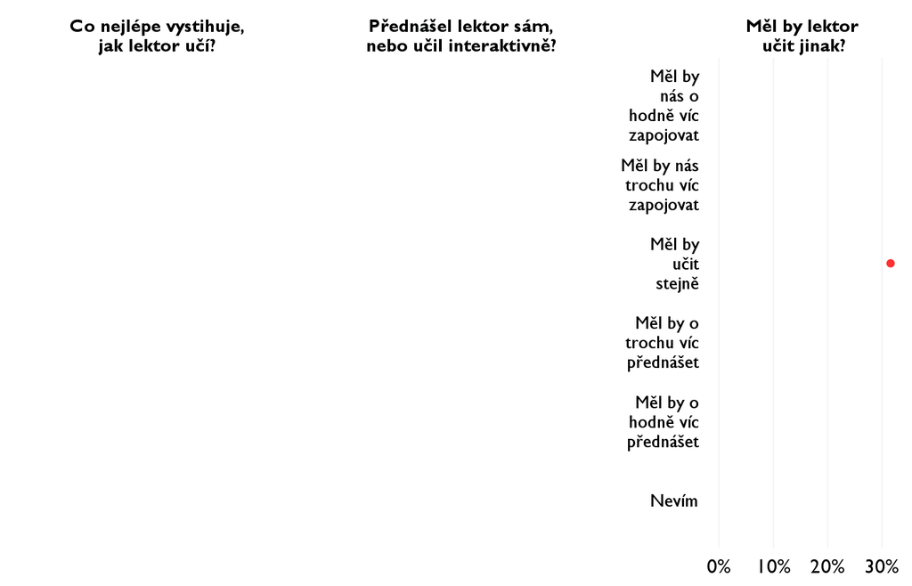

### Jak se studentům nejlépe učí?

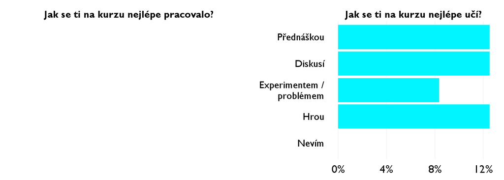

## Ovlivnil tě kurz nějak?

**Pokud ano, jak? Pokud ne, proč ne?**

- Ano v tom ze tuzim teraz viest debatny klub
- Snad umím líp argumentovat :D
- Ano, premyslim, ze zacnu debatovat!
- Rozhodne :) Ukázal mi nový pohľad na debatu a na to, ako ju možem využiť v praxi.
- Získala som systém v ako mojej debatě, tak aj v zivote
- Chcem sa naucit debatovat a zlepsit si prejav
- Pravděpodobně založím debatný klub
- Ovlivnil ma v tom ako vysvetlovat ludom věci a obhajovat si pred nimi názor.
- V pohledu na debatu.
- ano, chcela by som debatovat
- Ovplyvnil ma v tom ze odteraz budem vediet spravne argumentovat, obhajit si svoj nazor a taktiez brast ohlad aj na druhych. Tiez vo vnimani niektorych veci a tém.